# 08. Генетический offset на MVP: какой набор SNP подавать в модель — ADAPTOGENE

14 реплик · 9 наборов SNP · 3 метода offset · потолок из каузальных локусов и пол из нейтральных

## Обзор

```bash
if [ ! -f /mnt/data/eugene/ADAPTOGENE/work/journal/diagrams/08_00_abstract.svg ] || \
   [ /mnt/data/eugene/ADAPTOGENE/work/journal/diagrams/08_00_abstract.d2 -nt \
     /mnt/data/eugene/ADAPTOGENE/work/journal/diagrams/08_00_abstract.svg ]; then
  d2 --theme 200 --layout elk \
    /mnt/data/eugene/ADAPTOGENE/work/journal/diagrams/08_00_abstract.d2 \
    /mnt/data/eugene/ADAPTOGENE/work/journal/diagrams/08_00_abstract.svg
fi
```

[figure not shown]

# Часть I. Дизайн

## 1. Плечо offset было закрыто, и чем именно оно открылось

**Что стояло на пути.** `docs/gea_simulation_benchmarks.md` (критерий 8) и `benchmarks/capblancq_eval/FINDINGS.md` фиксировали одно и то же ограничение: депозит MVP выкладывает приспособленность **только в родном деме** — «fitness of the individual in the deme where it was sampled». Для offset нужна приспособленность тех же генотипов под **другим** оптимумом, то есть трансплантационная. План предполагал вывести её из Lotterhos 2023 Eq. 3 и сначала проверить этот вывод на депозите Capblancq, где приспособленность до и после сдвига выложена напрямую.

**Чем открылось.** Выводить ничего не нужно: функция приспособленности **читается из самих выложенных данных**. Депозит даёт для одних и тех же 1000 особей фенотипы (`phen_temp`, `phen_sal`), оптимумы демов (`bio_1`, `bio_2`) и реализованную приспособленность, поэтому регрессия

$$\log f_i = b_0 + b_1 (phen\_temp_i -
opt1_j)^2 + b_2 (phen\_sal_i - opt2_j)^2$$

либо воспроизводит модель точно, либо нет. Она воспроизводит: R² = **1.000000** на всех 14 репликах, максимум модуля остатка **< 1e-5**, свободный член **< 1e-7**. Это не подгонка, а тождество, и оно применяется к любому оптимуму без единого допущения, взятого из статьи.

**Коэффициенты посидовые — это несущая часть результата.** Три режима:

- `equal-S`, 2 признака: b₁ = **−1.000**, b₂ = **−1.000**
- `unequal-S`, 2 признака: b₁ = **−0.125**, b₂ = **−1.000** (сила отбора по признакам разная)
- 1 признак: b₁ = **−2.000**, b₂ = **0** (`sd(phen_sal)` = 0, ось инертна)

Единая захардкоженная функция приспособленности выдумала бы штраф по инертной оси на 4 репликах и взяла бы неверную силу отбора ещё на 4 — молча, без единого сообщения об ошибке.

**Следствие для плана.** Шаг «проверить генератор на Capblancq» (FINDINGS.md, п. 3) отпадает: он страховал риск неправильно переписать Eq. 3, а функция взята не из статьи, а из данных. Плечо α депозита Capblancq остаётся отдельной задачей и этим журналом не закрывается.

```r
check_files(c(
  "скрипт тождества"           = "/mnt/data/eugene/ADAPTOGENE/benchmarks/mvp_fitness_identity.R",
  "таблица коэффициентов"      = paste0(R8, "fitness_identity.tsv")
))
```

```
## [OK] скрипт тождества
## [OK] таблица коэффициентов
```

```bash
# НЕ ПЕРЕЗАПУСКАТЬ — выполнено 2026-08-05
nix shell nixpkgs#docker-client -c docker run --rm --user $(id -u):$(id -g) \
  -e USER=adaptogene -e OPENBLAS_NUM_THREADS=4 \
  -v /mnt/data/eugene/ADAPTOGENE:/pipeline adaptogene:latest \
  Rscript /pipeline/benchmarks/mvp_fitness_identity.R
```

```
##        seed             arch n_traits        b1        b2    R2 max_resid
##       <int>           <char>    <int>     <num>     <num> <num>     <num>
##  1: 1232568    mod-polygenic        2 -0.999999 -1.000000     1  6.61e-06
##  2: 1231578 highly-polygenic        2 -0.125000 -1.000000     1  7.59e-06
##  3: 1231288        oliogenic        2 -0.125000 -1.000001     1  6.90e-06
##  4: 1232578    mod-polygenic        2 -0.999999 -0.999999     1  6.81e-06
##  5: 1232548    mod-polygenic        2 -0.999999 -1.000000     1  7.33e-06
##  6: 1231858    mod-polygenic        1 -2.000000  0.000000     1  7.75e-06
##  7: 1232218        oliogenic        2 -0.125000 -1.000000     1  5.09e-06
##  8: 1231993        oliogenic        2 -0.125000 -1.000001     1  9.25e-06
##  9: 1232398        oliogenic        2 -1.000002 -1.000000     1  6.34e-06
## 10: 1233208    mod-polygenic        1 -1.999998  0.000000     1  8.48e-06
## 11: 1232923 highly-polygenic        2 -0.999999 -1.000001     1  8.15e-06
## 12: 1231798 highly-polygenic        2 -1.000000 -1.000000     1  6.37e-06
## 13: 1232908 highly-polygenic        1 -2.000000  0.000000     1  8.23e-06
```

[output cut: 17 more lines]

- Реплик проверено: **14**
- R² тождества: **1.000000** на всех (порог гейта 1 − 1e-6)
- Максимум модуля остатка по всем репликам: **< 1e-5**
- Режимов силы отбора: **3** (equal-S, unequal-S, 1-trait)
- Файл: `benchmarks/mvp_eval/offset08/fitness_identity.tsv`

Плечо offset на MVP открыто без единого допущения из статьи: трансплантационная приспособленность считается точно, для любого оптимума, по коэффициентам самой реплики. Это снимает шаг «сначала проверить генератор на депозите Capblancq» (`FINDINGS.md`, п. 3) — он страховал риск, которого здесь нет. Три режима силы отбора, которые видно в таблице, дальше оказываются **той самой** структурой, которая решает, различает ли реплика наборы SNP вообще (раздел 2).

## 2. Сценарий будущего климата и мишень оценки

**Скрипт:** `benchmarks/mvp_make_future_env.R`. Пишет два продукта на реплику: `data/mvp/MVP{seed}/MVP{seed}_env_future.tsv` (то, на что смотрит `Climate.custom.future_table`) и `benchmarks/mvp_eval/offset08/target_{seed}.tsv` (мишень).

Пространственно **однородный** сдвиг отвергнут сразу: он делает дистанцию переноса константой, и евклидов нуль — та планка, которую offset обязан перебить (0.33–0.77 на депозите Capblancq, ≈0.45 у Gain et al. 2023) — становится невычислимым, потому что у него нулевая дисперсия.

**Первая версия сценария — сдвиг одной оси, и почему она не работает.** Сдвигался только `bio_1`, амплитуда росла с запада на восток: `delta_j = 0.25 + 0.5 * (lon_j − lon_min)/(lon_max − lon_min)`, `bio_2` не трогался. Амплитуда бралась вдоль **долготы**, а не широты, потому что в этих симуляциях `bio_1` — точная линейная функция широты (корреляция **1.000**), и градиент по широте сделал бы «климатическую дистанцию» переименованной температурой; построенный сценарий давал R²(clim_dist ~ bio_1) = **4e-31**, то есть эту ловушку он обходил.

Но он попадал в другую, более серьёзную. Когда движение заперто на **одной** оси, любая квадратичная форма схлопывается в `sqrt(w11)·|delta1|` независимо от весов `w`, поэтому offset любого метода этого класса становится скалярным кратным дистанции переноса, и набор SNP не может на него повлиять **по построению**. Измерено на якорной реплике по всем девяти наборам:

было (сдвиг одной оси): `rda_offset` corr(offset, clim_dist) = **1.000000**, одинаково для всех **9** наборов; `geometric_offset` — **0.990267**, тоже одинаково для всех **9**; медиана ΔR² сверх нуля = **0.008** (geometric), **0** (RDA), **1e-5** (GF)

стало (сдвиг двух осей): `delta1` по `bio_1` **0.10 … 0.60** вдоль долготы (строго положительный, монотонный), `delta2` по `bio_2` — фиксированный розыгрыш из seq(**−0.5**, **+0.5**) по демам с seed **7**; `clim_dist = sqrt(delta1² + delta2²)`

Почему именно так:

- `delta1` **строго положительный и монотонный по долготе**. `bio_2` в этих симуляциях — точная «гора» по долготе (corr(bio_2, −|lon − mid|) = **−1.000**), поэтому центрированный на нуле сдвиг по долготе дал бы `|delta1|` в форме буквы V, то есть коллинеарный с `bio_2` (измерено: R² = **0.478**). Монотонный положительный `delta1` оставляет `|delta1|` монотонным.
- `delta2` — **розыгрыш**, а не градиент. После того как `delta1` занял единственное монотонное-по-долготе направление, любой оставшийся гладкий пространственный узор на решётке 10×10 коллинеарен либо с `bio_1` (широта), либо с `bio_2` (свёрнутая долгота). Псевдослучайное назначение по демам независимо от обоих по построению — тот же приём, что «новые климаты» в пайплайне MVP-offsets. Перестановка ключуется по **отсортированным именам демов** с фиксированным seed, поэтому у всех 14 реплик **один и тот же** сценарий и кросс-сидовые контрасты не загрязнены различиями сценариев.
- Проверяется на каждой сборке, а не декларируется: гейт падает, если |corr(delta1, delta2)| > **0.1** или если доля движения по оси 1 почти не варьирует между демами.

**Про нуль.** `clim_dist` — **невзвешенная** евклидова дистанция, то есть стандартный нуль и намеренно **неверная** метрика для реплик `1-trait` (b₂ = 0, движение по `bio_2` не стоит приспособленности) и `unequal-S` (b₁ = −0.125, b₂ = −1.000, движение по `bio_2` стоит в 8 раз дороже). Это рассогласование и есть запас: модель, выучившая правильные веса осей из генотипов, может его забрать, а модель, измеряющая «насколько далеко уехал климат», — нет. Колонка `headroom` (R² оракульной взвешенной модели минус R² нуля) в таблице ниже показывает, где этот запас вообще есть.

**Мишень.** Трансплантационная приспособленность точна (раздел 1), поэтому на дем считается реализованное падение

`delta_logf_j = mean_i [ log f_i(future) - log f_i(present) ]`,

без переадаптации и без прошедших поколений — та же конструкция, что у колонки `fitness_pred`, которую выкладывает депозит Capblancq. Особи берутся из **собственного списка пайплайна** (`{PROJECT}_results/_intermediate/samples/metadata_climate.tsv`), а не из сырой метаданной таблицы депозита: фильтрация может выкинуть образцы, и среднее по дему, посчитанное по особям, которых модель не видела, разошлось бы молча.

```r
check_files(c(
  "скрипт сценария"     = "/mnt/data/eugene/ADAPTOGENE/benchmarks/mvp_make_future_env.R",
  "сводка мишени"       = paste0(R8, "target_summary.tsv"),
  "мишень (пример)"     = paste0(R8, "target_1232548.tsv"),
  "future env (пример)" = "/mnt/data/eugene/ADAPTOGENE/data/mvp/MVP1232548/MVP1232548_env_future.tsv"
))
```

```
## [OK] скрипт сценария
## [OK] сводка мишени
## [OK] мишень (пример)
## [OK] future env (пример)
```

```bash
# НЕ ПЕРЕЗАПУСКАТЬ — выполнено 2026-08-05
nix shell nixpkgs#docker-client -c docker run --rm --user $(id -u):$(id -g) \
  -e USER=adaptogene -e OPENBLAS_NUM_THREADS=4 \
  -v /mnt/data/eugene/ADAPTOGENE:/pipeline adaptogene:latest \
  Rscript /pipeline/benchmarks/mvp_make_future_env.R
```

```bash
# [изменено 2026-08-05] сдвиг одной оси -> сдвиг двух осей (см. блоки было/стало выше).
# Флаг --force=true обязателен: скрипт по умолчанию отказывается перезаписывать уже
# существующую таблицу сценария — это входной файл, и молчаливая перезапись входа запрещена.
nix shell nixpkgs#docker-client -c docker run --rm --user $(id -u):$(id -g) \
  -e USER=adaptogene -e OPENBLAS_NUM_THREADS=4 \
  -v /mnt/data/eugene/ADAPTOGENE:/pipeline adaptogene:latest \
  Rscript /pipeline/benchmarks/mvp_make_future_env.R --force=true
```

```
##        seed dlogf_med demes_gain null_R2 oracle_R2 headroom cor_d1d2 R2_dist_b1
##       <int>     <num>      <int>   <num>     <num>    <num>    <num>      <num>
##  1: 1232568    -0.209          9   0.522     0.517   -0.005    0.017     0.0065
##  2: 1231578    -0.068         11   0.263     0.368    0.105    0.017     0.0065
##  3: 1231288    -0.080         18   0.215     0.403    0.188    0.017     0.0065
##  4: 1232578    -0.204          3   0.523     0.526    0.003    0.017     0.0065
##  5: 1232548    -0.193          7   0.458     0.440   -0.018    0.017     0.0065
##  6: 1231858    -0.222         11   0.471     0.610    0.139    0.017     0.0065
##  7: 1232218    -0.055         26   0.059     0.137    0.078    0.017     0.0065
##  8: 1231993    -0.083         17   0.150     0.288    0.138    0.017     0.0065
##  9: 1232398    -0.197         10   0.618     0.624    0.006    0.017     0.0065
## 10: 1233208    -0.264          9   0.492     0.711    0.219    0.017     0.0065
## 11: 1232923    -0.173          3   0.563     0.546   -0.016    0.017     0.0065
## 12: 1231798    -0.228          6   0.661     0.673    0.011    0.017     0.0065
## 13: 1232908    -0.223          1   0.472     0.711    0.239    0.017     0.0065
```

[output cut: 17 more lines]

было (сдвиг одной оси): нуль климатической дистанции R² **0.016 … 0.738**; R²(clim_dist ~ bio_1) = **4e-31**; демов, выигрывающих от сдвига, **0–27**

стало (сдвиг двух осей):

- Демов на реплику: **100**, особей **1000**
- Сдвиг: `bio_1` **+0.10 … +0.60**, `bio_2` **−0.50 … +0.50** (единицы среды, градиент [−1, 1])
- Независимость осей сдвига: corr(delta1, delta2) = **0.017**
- Ортогональность нуля к настоящей среде на 12 репликах `SS-Mtn`: R²(clim_dist ~ bio_1) = **0.007**, R²(clim_dist ~ bio_2) = **0.000**; на 2 контролях `Est-Clines` — **0.742** по `bio_2` (у них другая геометрия Env2, один общий сценарий не может быть ортогонален обеим)
- Нуль климатической дистанции, R² по репликам: **0.06 … 0.66**
- Запас оракульной взвешенной модели над нулём (`headroom`): **0.00 … 0.24**
- Демы, выигрывающие от сдвига: **1–26** на реплику
- Файлы: `target_{seed}.tsv` (14 шт.), `target_summary.tsv`

Запас над нулём распределён не случайно, а **по режимам силы отбора**, и это и есть структура, которую журнал может измерять:

- `equal-S` (b₁ = b₂ = −1): запас **0.00 … 0.01**. Невзвешенная евклидова дистанция здесь — **правильная** метрика, поэтому никакая генетическая информация не может улучшить нуль. Эти реплики не различают наборы SNP в принципе.
- `unequal-S` (b₁ = −0.125, b₂ = −1): запас **0.08 … 0.19**.
- `1-trait` (b₁ = −2, b₂ = 0): запас **0.14 … 0.24**.

## 3. Девять наборов SNP: три кандидата, потолок и пол

**Скрипт:** `benchmarks/mvp_build_snp_sets.R`. Пишет наборы прямо в хранилище, которое `resolve_active_snp_sets()` (`workflow/rules/common.smk:1207`) глобит на этапе разбора: `{PROJECT}_results/_intermediate/snp_sets/{name}/selected_snps.tsv` в схеме `scripts/promote_snp_set.R` (SNPID, chr, pos, min_pvalue) плюс `manifest.json`.

**Кандидаты** — три, и они отличаются **только правилом объединения**:

- `best` — схема **S1** из `benchmarks/mvp_anchor_schemes.tsv`: LFMM+RDA+EMMAX, согласие **≥ 2** методов в окне **5 кб**.
- `union` — те же три метода, правило `union`, окно 0 (максимизация полноты).
- `solo` — только LFMM, та же рабочая точка (одиночный метод).

**Калибровка перенесена, а не выведена из истины.** Помодельные рабочие точки взяты у S1 **verbatim** — LFMM `top_100`, RDA `top_100`, EMMAX `custom 1e-04`, зафиксированные на якорной реплике в журнале 06. Это режим `verbatim` журнала 07: применение этих точек к новой реплике не требует истины, поэтому наборы воспроизводимы на реальных данных. Режим `recal` (переизбор точек по истине этой же реплики) намеренно **не** используется — он занёс бы ответ внутрь кандидатов.

Почему не собственный `bonf 0.05` пайплайна, что было бы естественнее: измерено на всех 14 репликах на их дефолтных рунгах — он даёт **0–34** SNP на метод, RDA даёт **0** на 8 репликах из 14, и `best` (согласие ≥ 2 методов) выходит **пустым** на большинстве реплик. `qval 0.1` хуже: **0** вызовов везде (оценка π₀ вырождается на этих распределениях p). `custom 1e-04` даёт **0–62**. Только точки `top_N` дают наборы того размера, который вообще можно подать в модель offset.

**Потолок** `truth` — каузальные локусы реплики, пережившие фильтрацию (**6 … 515**). **Пол** `rand_*` — розыгрыши **только из `background_neutral`**: в таблице истины 1232548 стоит 70 каузальных / 5207 `linked_neutral` / 5048 `background_neutral`, поэтому наивный `sample(all_snps)` дал бы примерно половину сцепленных с настоящими QTN локусов — это не нуль. Три независимых розыгрыша размера `best` (один розыгрыш выдал бы свой шум за эффект метода) плюс по одному размера `union` и `solo`, чтобы **у каждого кандидата был пол его собственного размера** и размер набора не путался с его качеством.

Рабочая точка каждого метода берётся с его собственного рунга `is_default` в `benchmarks/mvp_sweep_cells*.tsv` (LFMM K = k_best, EMMAX/RDA n_pcs = k_best). На репликах с малым `k_best` лестницы расходятся — дефолт LFMM попадает в `c2`, а EMMAX/RDA остаются в `c3`, — поэтому рунг ищется по паре (реплика, метод), а не назначается одной ячейкой.

```r
check_files(c(
  "скрипт наборов"  = "/mnt/data/eugene/ADAPTOGENE/benchmarks/mvp_build_snp_sets.R",
  "сводка наборов"  = paste0(R8, "snp_sets_summary.tsv"),
  "набор (пример)"  = "/mnt/data/eugene/ADAPTOGENE/MVP1232548_results/_intermediate/snp_sets/best/selected_snps.tsv"
))
```

```
## [OK] скрипт наборов
## [OK] сводка наборов
## [OK] набор (пример)
```

```bash
# НЕ ПЕРЕЗАПУСКАТЬ — выполнено 2026-08-05
nix shell nixpkgs#docker-client -c docker run --rm --user $(id -u):$(id -g) \
  -e USER=adaptogene -e OPENBLAS_NUM_THREADS=4 \
  -v /mnt/data/eugene/ADAPTOGENE:/pipeline adaptogene:latest \
  Rscript /pipeline/benchmarks/mvp_build_snp_sets.R
```

```
## Размер набора (число SNP):
##
## Key: <seed>
##        seed  best rand_best1  solo truth union
##       <int> <int>      <int> <int> <int> <int>
##  1: 1231288   121        121   198     6   218
##  2: 1231578   141        141   198   515   218
##  3: 1231798   160        160   197   395   231
##  4: 1231858   166        166   197    46   240
##  5: 1231993   158        158   197     8   218
##  6: 1232218   139        139   198     6   219
##  7: 1232398   154        154   197    10   218
##  8: 1232548   156        156   176    70   217
##  9: 1232568   165        165   193    38   219
## 10: 1232578   175        175   182    28   260
```

[output cut: 24 more lines]

- Наборов на реплику: **9** (3 кандидата + потолок + 5 розыгрышей пола)
- `best`: **121 … 177** SNP, из них каузальных **3 … 24**
- `union`: **217 … 260** SNP, каузальных **4 … 30**
- `solo`: **176 … 198** SNP, каузальных **4 … 29**
- `truth`: **6 … 515** SNP (все каузальные, переживших фильтрацию)
- Структурные проверки: в `rand_*` **0** каузальных и **0** сцепленных локусов; `union ⊇ best` на всех репликах

Размер кандидатов почти постоянен между репликами (это следствие точки `top_N`), а число каузальных локусов — нет (**6 … 515**). Поэтому `best` покрывает большую долю истины на олигогенных репликах и малую на полигенных, и сравнивать абсолютные значения ρ между репликами нельзя — только внутрисидовые контрасты с собственным полом и собственным потолком.

Роспись устроена так, что каждый кандидат сравнивается с полом **своего размера**: `best` — с медианой трёх розыгрышей размера `best`, `union` — с розыгрышем размера `union`, `solo` — своего. Без этого «больший набор лучше» и «лучший набор лучше» были бы неразличимы. Потолок `truth` — не рекомендация, а верхняя отметка: он показывает, сколько сигнала вообще доступно на этой реплике при этом сценарии.

## 4. Методы offset и почему все они nospatial

Прогоняются все три метода реестра `workflow/methods/maladaptation.py`:

- `gradient_forest` — `ntree` **500**, `cor_threshold` **0.5**;
- `geometric_offset` — `LEA::genetic.gap()`, `scale: true`, `k` пустой (берётся `sNMF.k_best` реплики);
- `rda_offset` — `axes: auto`, `axis_alpha` **0.05**, `permutations` **999**, `condition_pcs` **0** (каноника, `docs/rda_research.md` B7), `seed` **42**.

`spatial_correction: without` у всех: `geometric_offset` и `rda_offset` объявлены nospatial-only ограничением на wildcard (`workflow/rules/maladaptation.smk`), а `mode=climate` для проектов MVP никогда не запускался, поэтому `climate/tables/{spatial,varpart}/` пусты и пространственному GF просто нечего подать на вход. Единый nospatial заодно делает три метода сравнимыми между собой.

`random_model: false`. Нейтральная модель GF кормит **только** графики кумулятивной и общей важности и **никогда** не доходит до offset — она не может служить случайным контролем для предсказания. Поэтому случайный контроль здесь сделан **набором SNP** (`rand_*`), который проходит через все три метода наравне с остальными.

# Часть II. Прогон

## 5. Конфиги: базовый файл плюс ровно две вставки

**Скрипт:** `benchmarks/mvp_write_offset_configs.R`. Генерирует `config_MVP{seed}_off.yaml` как текстовый патч базового `config_MVP{seed}.yaml`, добавляя **только**:

1. `Climate.custom.future_table` — таблица сценария из раздела 2;
2. блок `Maladaptation:` — три метода, nospatial, `snp_sets: all`.

`project_name` не меняется, поэтому прогон попадает в **тот же** `{PROJECT}_results/` и переиспользует весь апстрим (импутированные матрицы, PCA, кинship, застейдженный настоящий климат), ничего не пересчитывая. Опасность «два конфига — одно `project_name`», описанная в `CLAUDE.md`, здесь используется намеренно и безопасна ровно потому, что апстрим у двух конфигов идентичен **по построению**: генерация вместо ручной правки — это и есть гарантия. Скрипт проверяет её сам: `diff` базового и сгенерированного файла обязан содержать **0** удалённых строк, иначе он падает.

`snp_sets: all` вместо перечисления: реестр наборов глобится, поэтому реплика, на которой какой-то набор вышел пустым, просто не получает соответствующей директории и прогон не падает.

```r
check_files(c(
  "генератор конфигов"   = "/mnt/data/eugene/ADAPTOGENE/benchmarks/mvp_write_offset_configs.R",
  "конфиг (пример)"      = "/mnt/data/eugene/ADAPTOGENE/config_MVP1232548_off.yaml"
))
```

```
## [OK] генератор конфигов
## [OK] конфиг (пример)
```

```r
cfgs <- list.files("/mnt/data/eugene/ADAPTOGENE", pattern = "^config_MVP[0-9]+_off\\.yaml$")
cat("Сгенерировано конфигов:", length(cfgs), "\n")
```

```
## Сгенерировано конфигов: 14
```

```bash
# НЕ ПЕРЕЗАПУСКАТЬ — выполнено 2026-08-05
nix shell nixpkgs#docker-client -c docker run --rm --user $(id -u):$(id -g) \
  -e USER=adaptogene -v /mnt/data/eugene/ADAPTOGENE:/pipeline adaptogene:latest \
  Rscript /pipeline/benchmarks/mvp_write_offset_configs.R

# Проверка контракта «апстрим не тронут» (одна реплика для примера):
diff /mnt/data/eugene/ADAPTOGENE/config_MVP1232548.yaml \
     /mnt/data/eugene/ADAPTOGENE/config_MVP1232548_off.yaml
```

- Конфигов сгенерировано: **14**
- Добавлено строк на файл: **+32**, удалено: **0**
- Единственные изменённые ключи: `Climate.custom.future_table`, блок `Maladaptation`

## 6. Прогон `mode=maladaptation` на 14 репликах

**Скрипт:** `benchmarks/mvp_offset_run.sh`. Реплики независимы (свой `{PROJECT}_results/`, свой лок Snakemake), поэтому идут **параллельно**; внутри реплики режим ровно один, так что правило «не запускать два режима одного проекта одновременно» выполнено по построению.

- бюджет: **120** CPU и **600** ГБ на все наши контейнеры;
- сторож RAM: раз в **30 с** сравнивает суммарную занятость хоста с потолком **900 ГБ** и при превышении останавливает **наш** самый крупный контейнер (`off08_*`), никогда чужой — машина общая;
- `-e USER=adaptogene` обязателен (иначе `getpass.getuser()` в snakemake падает под `--user`), `OPENBLAS_NUM_THREADS`/`OMP_NUM_THREADS` обязательны (контейнер видит 192 ядра хоста).

DAG одной реплики: **113** заданий — 9 наборов × 3 метода плюс графики и стейджинг будущего климата.

```r
logs <- list.files(paste0(R8, "runlogs"), pattern = "^MVP[0-9]+\\.log$", full.names = TRUE)
done <- vapply(logs, function(f) any(grepl("DONE", readLines(f, warn = FALSE))), logical(1))
cat("Логов прогона:", length(logs), " из них DONE:", sum(done), "\n")
```

```
## Логов прогона: 14  из них DONE: 14
```

```r
SCr <- rd(paste0(R8, "scores.tsv"), colClasses = c("seed" = "character"))
if (!is.null(SCr)) cat("Строк (реплика × метод × набор) в scores.tsv:", nrow(SCr), "\n")
```

```
## Строк (реплика × метод × набор) в scores.tsv: 378
```

```bash
# НЕ ПЕРЕЗАПУСКАТЬ — выполнено 2026-08-05
/mnt/data/eugene/ADAPTOGENE/benchmarks/mvp_offset_run.sh all 7 16
```

# Часть III. Результаты

## 7. Переносит ли offset сигнал вообще: потолок против пола

```
## Медиана ρ Спирмена (offset против падения приспособленности), 12 реплик SS-Mtn:
##
## Key: <set, role>
##            set      role geometric_offset gradient_forest rda_offset
##         <char>    <char>            <num>           <num>      <num>
## 1:        best candidate        0.8001680       0.6110771  0.7776058
## 2:  rand_best1     floor        0.8137894       0.6938254  0.8179058
## 3:  rand_best2     floor        0.8255986       0.6922052  0.8240384
## 4:  rand_best3     floor        0.8122772       0.6674587  0.8085689
## 5:  rand_solo1     floor        0.8249145       0.6903450  0.8186259
## 6: rand_union1     floor        0.8254665       0.6858806  0.8234863
## 7:        solo candidate        0.8101770       0.6313951  0.7894869
## 8:       truth   ceiling        0.8027843       0.6917012  0.8021482
## 9:       union candidate        0.8026883       0.6396640  0.7862226
```

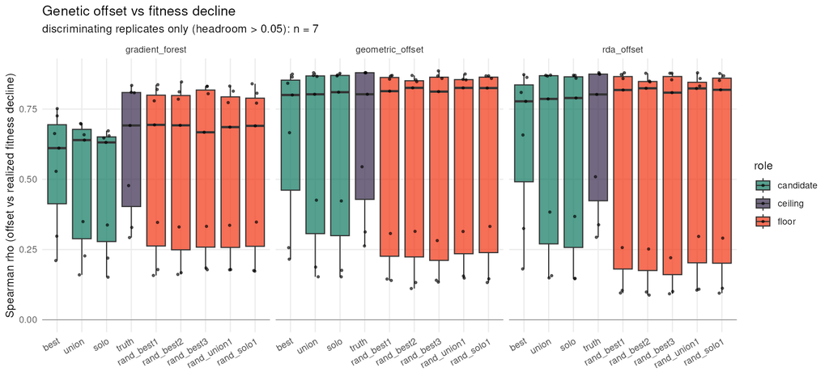

## 8. Меняет ли набор SNP вообще хоть что-нибудь: инвариантность ранжирования

Прежде чем сравнивать наборы между собой, проверяется предпосылка, которую бенчмарки offset обычно принимают на веру: **влияет ли выбор SNP на порядок демов вообще**. Для каждой пары (реплика, метод) берутся девять векторов offset по демам и считаются попарные корреляции Пирсона и Спирмена, плюс разброс отношения `offset_set_j / offset_set_1` по демам. Если два набора дают векторы, отличающиеся ровно на скалярный множитель, то ранжирование демов у них одно и то же, и для этого метода вопрос «какие SNP подавать» **не имеет содержания** — меняется только абсолютная величина, про которую собственная диагностика `rda_offset` и так говорит «report as a RELATIVE SITE RANKING only».

```
##              method n_реплик min_Pearson_мед min_Spearman_мед
##              <char>    <int>           <num>            <num>
## 1:  gradient_forest       14        0.814922         0.819430
## 2: geometric_offset       14        0.929542         0.947195
## 3:       rda_offset       14        0.874389         0.879544
##    разброс_отношения_мед
##                    <num>
## 1:                 1.600
## 2:                 0.888
## 3:                 0.765
```

- Минимальная попарная корреляция Пирсона между девятью наборами, медиана по 14 репликам: `gradient_forest` **0.81**, `rda_offset` **0.87**, `geometric_offset` **0.93**
- Разброс отношения `offset_j / offset_1` по демам: **0.77 … 1.60** (то есть отношение не константа — векторы не пропорциональны)
- На сценарии **с одной подвижной осью** (первая версия, раздел 2) те же величины были вырожденными: отношение постоянно с точностью **1e-15**, попарная корреляция **1.000000**

При сдвиге двух осей набор SNP **меняет** порядок демов у всех трёх методов, то есть вопрос файла содержателен. Сильнее всего порядок двигает `gradient_forest` (медиана минимальной корреляции **0.81**), слабее всего — `geometric_offset` (**0.93**). Дальше выясняется, что «двигает сильнее» и «двигает в сторону истины» — разные вещи: именно GF получает от курирования набора наибольший **вред** (раздел 9).

## 9. Кандидаты против собственного пола и собственного потолка

```
##              method    set n_seeds n_beat_floor   rho_med floor_med ceiling_med
##              <char> <char>   <int>        <int>     <num>     <num>       <num>
## 1:  gradient_forest  union       7            2 0.6396640 0.6858806   0.6917012
## 2:  gradient_forest   solo       7            1 0.6313951 0.6903450   0.6917012
## 3:  gradient_forest   best       7            3 0.6110771 0.6922052   0.6917012
## 4: geometric_offset   solo       7            6 0.8101770 0.8249145   0.8027843
## 5: geometric_offset  union       7            5 0.8026883 0.8254665   0.8027843
## 6: geometric_offset   best       7            5 0.8001680 0.8137894   0.8027843
## 7:       rda_offset   solo       7            5 0.7894869 0.8186259   0.8021482
## 8:       rda_offset  union       7            5 0.7862226 0.8234863   0.8021482
## 9:       rda_offset   best       7            4 0.7776058 0.8179058   0.8021482
##    gap_to_ceiling_med
##                 <num>
## 1:        0.128172817
## 2:        0.140258026
## 3:        0.082244224
## 4:        0.011473147
## 5:        0.013333333
## 6:        0.006276628
## 7:        0.015181518
## 8:        0.015925593
## 9:        0.016705671
```

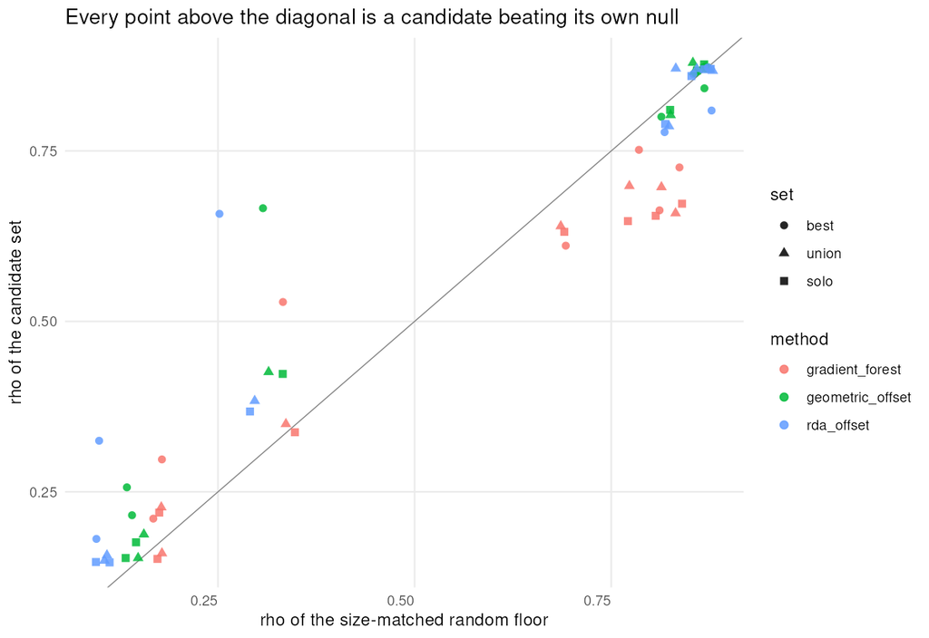

```
## Преимущество над полом своего размера (ρ кандидата − ρ пола), медиана по архитектурам:
##
## Key: <arch, set>
##                arch    set geometric_offset gradient_forest rda_offset
##              <char> <char>            <num>           <num>      <num>
## 1: highly-polygenic   best           -0.011          -0.091     -0.034
## 2: highly-polygenic   solo            0.006          -0.138      0.001
## 3: highly-polygenic  union            0.010          -0.124      0.014
## 4:    mod-polygenic   best           -0.003          -0.096     -0.016
## 5:    mod-polygenic   solo           -0.003          -0.113     -0.014
## 6:    mod-polygenic  union           -0.006          -0.082     -0.013
## 7:        oliogenic   best            0.122           0.119      0.226
## 8:        oliogenic   solo            0.030          -0.010      0.052
## 9:        oliogenic  union            0.032           0.013      0.048
##
## Сколько реплик, где кандидат бьёт свой пол:
##
## Key: <arch, set>
##                arch    set geometric_offset gradient_forest rda_offset
##              <char> <char>           <char>          <char>     <char>
## 1: highly-polygenic   best              1/2             0/2        0/2
## 2: highly-polygenic   solo              2/2             0/2        1/2
## 3: highly-polygenic  union              1/2             0/2        1/2
## 4:    mod-polygenic   best              1/2             0/2        1/2
## 5:    mod-polygenic   solo              1/2             0/2        1/2
## 6:    mod-polygenic  union              1/2             0/2        1/2
## 7:        oliogenic   best              3/3             3/3        3/3
## 8:        oliogenic   solo              3/3             1/3        3/3
## 9:        oliogenic  union              3/3             2/3        3/3
```

Медиана (ρ кандидата − ρ пола того же размера), 7 различающих реплик:

Осторожность: в этой панели олигогенные реплики совпадают с режимом `unequal-S`, поэтому «выигрыш от олигогенности» и «выигрыш от анизотропного отбора» здесь **не разделены** — см. раздел 13, п. 8.

## 10. Прирост сверх нуля климатической дистанции

```
## Медиана ΔR² (полная модель − нуль клим. дистанции):
##
## Key: <set, role>
##            set      role geometric_offset gradient_forest rda_offset
##         <char>    <char>            <num>           <num>      <num>
## 1:        best candidate        0.1464019      0.04422610  0.1079562
## 2:  rand_best1     floor        0.1576712      0.02248680  0.1442416
## 3:  rand_best2     floor        0.1403718      0.01847650  0.1452545
## 4:  rand_best3     floor        0.1695311      0.03581140  0.1650953
## 5:  rand_solo1     floor        0.1541113      0.02481629  0.1393545
## 6: rand_union1     floor        0.1404656      0.02360020  0.1454598
## 7:        solo candidate        0.1137254      0.01310669  0.1106532
## 8:       truth   ceiling        0.1277365      0.03711014  0.1309300
## 9:       union candidate        0.1074744      0.01344448  0.1059856
```

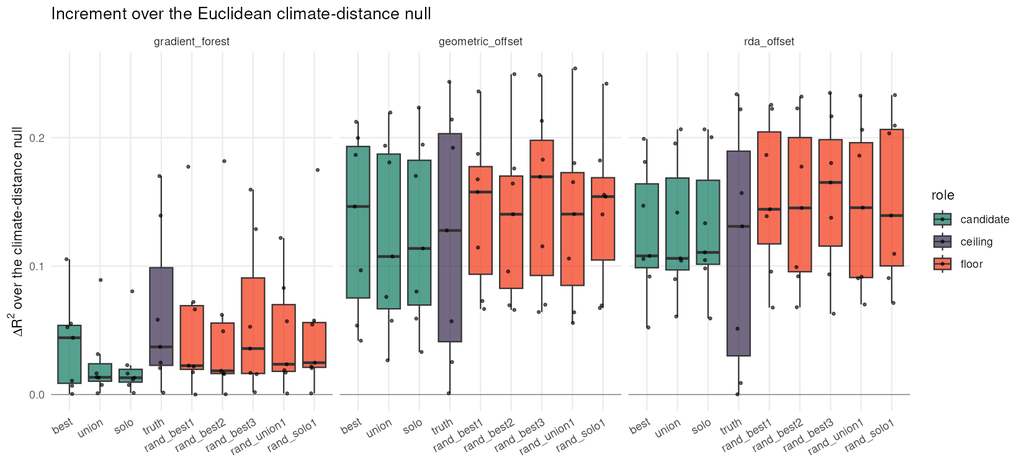

## 11. По стратам архитектуры и режимам отбора

```
## Key: <arch, set>
##                 arch    set geometric_offset gradient_forest rda_offset
##               <char> <char>            <num>           <num>      <num>
##  1: highly-polygenic   best        0.8581518       0.7072967  0.8409181
##  2: highly-polygenic   solo        0.8742514       0.6509931  0.8651125
##  3: highly-polygenic  truth        0.8793999       0.8221122  0.8744614
##  4: highly-polygenic  union        0.8746415       0.6786739  0.8692889
##  5:    mod-polygenic   best        0.8321692       0.6684608  0.8202220
##  6:    mod-polygenic   solo        0.8391119       0.6520132  0.8296610
##  7:    mod-polygenic  truth        0.8411521       0.7498950  0.8408461
##  8:    mod-polygenic  union        0.8344374       0.6682988  0.8282268
##  9:        oliogenic   best        0.2566097       0.2975578  0.3249325
## 10:        oliogenic   solo        0.1759976       0.2196100  0.1471107
## 11:        oliogenic  truth        0.3126553       0.3287249  0.3381578
## 12:        oliogenic  union        0.1875908       0.2273867  0.1569877
```

```
##
## По режиму силы отбора (все 12 нештрафных реплик), ρ:
##
## Key: <regime, set>
##        regime        set geometric_offset gradient_forest rda_offset
##        <char>     <char>            <num>           <num>      <num>
##  1:   1-trait       best        0.8530273       0.6943894  0.8360636
##  2:   1-trait rand_best1        0.8625623       0.7996100  0.8658026
##  3:   1-trait       solo        0.8697750       0.6509931  0.8648245
##  4:   1-trait      truth        0.8793999       0.8090009  0.8744614
##  5:   1-trait      union        0.8680468       0.6778158  0.8689109
##  6:   equal-S       best        0.7182358       0.6274947  0.7178998
##  7:   equal-S rand_best1        0.7119952       0.6927933  0.6856766
##  8:   equal-S       solo        0.7078068       0.6027963  0.7096550
##  9:   equal-S      truth        0.7278368       0.6764956  0.7335854
## 10:   equal-S      union        0.7098590       0.6366637  0.7027783
## 11: unequal-S       best        0.6660066       0.5284368  0.6577858
## 12: unequal-S rand_best1        0.3071947       0.3466187  0.2570057
## 13: unequal-S       solo        0.4229943       0.3374257  0.3678488
## 14: unequal-S      truth        0.5446985       0.4776838  0.5092229
## 15: unequal-S      union        0.4257546       0.3495110  0.3834263
##
## Запас оракульной взвешенной модели над нулём, по режимам:
##
##       regime headroom_med
##       <char>        <num>
## 1:   1-trait        0.196
## 2:   equal-S        0.003
## 3: unequal-S        0.078
```

Запас над нулём и польза от курирования — **разные** вещи, и это главный контринтуитивный результат раздела. Наибольший запас у реплик `1-trait` (**0.196**), но именно там отбор SNP работает хуже случайного набора: чтобы забрать этот запас, модели нужно выучить, что вторая ось не стоит приспособленности, а для этого полезнее много маркеров, отражающих общую структуру среды, чем сотня отобранных по ассоциации с обеими осями. Наоборот, `unequal-S` даёт скромный запас (**0.078**), но именно там отобранный набор бьёт и пол, и потолок.

## 12. Контроли `Est-Clines`

```
## Key: <seed, set>
##        seed         set geometric_offset gradient_forest rda_offset
##      <char>      <char>            <num>           <num>      <num>
##  1: 1231578        best        0.3727693      0.25680168  0.3225563
##  2: 1231578  rand_best1        0.2814041      0.11649565  0.2827963
##  3: 1231578  rand_best2        0.3414461      0.19057906  0.2961416
##  4: 1231578  rand_best3        0.2819082      0.14959496  0.2827963
##  5: 1231578  rand_solo1        0.3206601      0.10960696  0.3079148
##  6: 1231578 rand_union1        0.2819082      0.06033003  0.2827963
##  7: 1231578        solo        0.3396340      0.19600360  0.2861446
##  8: 1231578       truth        0.3411461      0.18622262  0.2822922
##  9: 1231578       union        0.3418662      0.21743774  0.2814041
## 10: 1232568        best        0.7149595      0.45668167  0.6969577
## 11: 1232568  rand_best1        0.6670987      0.43780378  0.6654545
## 12: 1232568  rand_best2        0.6723672      0.50859886  0.6670987
## 13: 1232568  rand_best3        0.6772517      0.56410441  0.6670987
## 14: 1232568  rand_solo1        0.6761836      0.59038704  0.6670987
## 15: 1232568 rand_union1        0.6705191      0.58149415  0.6663306
## 16: 1232568        solo        0.7027663      0.47067507  0.6670987
## 17: 1232568       truth        0.7143834      0.63871587  0.7038944
## 18: 1232568       union        0.7022982      0.52974497  0.6709031
```

Контроли `Est-Clines` (**1231578**, **1232568**, R²(PC1~temp) **0.92–0.94**) исключены из всех агрегатов по построению — как в журналах 06–07. У них к тому же **единственных** дистанция переноса скоррелирована с настоящей средой (R²(clim_dist ~ bio_2) = **0.742** против **0.000** на 12 репликах `SS-Mtn`), потому что геометрия Env2 у них другая, а сценарий один на всех. Поэтому их числа читаются только внутри своей строки и ни с чем в разделах 7–11 не сравниваются.

## 13. Ограничения этих тестов

**1. Базовая линия «все SNP» вне области файла.** Роспись наборов — `best`/`union`/`solo` против потолка и пола; набора «весь отфильтрованный VCF», который в литературе по offset используется чаще всего, здесь нет. Следствие: журнал ранжирует стратегии отбора между собой и относительно потолка/пола, но **не** отвечает, бьёт ли хоть одна из них подачу всех SNP. Добавляется одним набором на реплику, когда понадобится.

**2. Один сценарий будущего климата.** Сдвиг по обеим осям, `bio_1` **+0.10 … +0.60** вдоль долготы и `bio_2` розыгрышем **±0.5** по демам, один и тот же для всех 14 реплик. Ручка сложности здесь — не величина сдвига, а посидовая сила отбора (b₁, b₂): разброс нуля **0.06 … 0.66** и запаса **0.00 … 0.24** получен «бесплатно», а не спроектирован. Сценариев другой геометрии (сжатие градиента, сдвиг с поворотом, транспланты «дем в дем») не проверялось.

**2a. Сценарий с одной подвижной осью непригоден для этого вопроса — и это относится к целому классу бенчмарков offset, а не к этим методам.** Первая версия сценария (раздел 2) двигала только `bio_1`. При движении по одной оси любая квадратичная форма схлопывается в `sqrt(w11)·|delta1|` независимо от весов, поэтому offset любого метода этого класса становится скалярным кратным дистанции переноса. Измерено: `rda_offset` corr(offset, clim_dist) = **1.000000** и `geometric_offset` **0.990267**, причём **одинаково для всех девяти наборов SNP**. Никакой отбор SNP на таком сценарии не может ни на что повлиять — не потому, что отбор бесполезен, а потому что сценарий стирает различия. Любой бенчмарк генетического offset, сдвигающий один предиктор, измеряет не то, что заявляет.

**2b. Реплики `equal-S` не различают наборы по построению.** Когда b₁ = b₂, правильная метрика — **невзвешенная** евклидова дистанция, то есть в точности нуль. Запас оракульной взвешенной модели над нулём на этих репликах **0.00 … 0.01**, поэтому они не могут дать сигнала о выборе набора SNP ни в какую сторону. Основные агрегаты считаются по **различающим** репликам (`headroom` > 0.05), `equal-S` вынесены в `by_regime.tsv` и не выброшены молча.

**3. Одно плечо MAF.** Только `Filter.maf: 0.01`. Плечо 0.05 не запускалось, потому что потолок обязан содержать все каузальные локусы (на 1232548 при 0.05 их остаётся 43 из 70), а вопрос файла — какие SNP подавать, а не как фильтровать по частоте.

**4. Помодельные рабочие точки перенесены с одной якорной реплики.** Точки `top_100` / `custom 1e-04` зафиксированы на 1232548 в журнале 06. Журнал 07 уже измерил, что калибровка не переносится (разрыв `verbatim` против `recal`); здесь она перенесена сознательно, потому что альтернатива — переизбирать точки по истине каждой реплики — сделала бы кандидатов оракульными.

**5. Одна симуляционная модель.** Все 14 реплик — один депозит (Lotterhos 2023), одна модель SLiM, 100 демов на решётке 10×10, два климатических предиктора. Реальные проекты репозитория используют **19** предикторов; преимущество методов, работающих с композитными осями (RDA), на двух предикторах проявиться не может — ограничение унаследовано от журналов 06 §13.1 и 07 §13.3 целиком.

**6. Мишень — мгновенная трансплантация.** Ни переадаптации, ни миграции, ни демографии после сдвига: `delta_logf` считается по тем же фенотипам под новым оптимумом. Это ровно та конструкция, которую использует депозит Capblancq для своей колонки `fitness_pred`, и она измеряет **потенциальную** маладаптацию, а не судьбу популяции.